# Dplyr + GGPlot

David Griswold

7/20/2018

# Review: Group By and Summarise

## Why is this important

- A lot of time we have individual data and questison about the whole.
- Examples:
  - User sessions data but quesitons about the site’s expierence
  - Data by the week and questions about the year
  - Data on the passenger but questions about the titanic
- Using this functionality let’s us bridge those gaps efficently

## Pratice It

### Read Data in

```r
library(tidyverse)
library(magrittr)
titanicData <- read.csv("../titanic.csv")
```

## Breif Digression Using NyC Flights Dataset

Sometimes, we are dealing with a response that is continous rather than binary like the titanic dataset. R has a few that are baked in.

```r
flightData <- nycflights13::flights

# Factorize where necessary
flightData$carrier <- as.factor(flightData$carrier)
flightData$origin <- as.factor(flightData$origin)
flightData$dest <- as.factor(flightData$dest)
```

### Why do factor’s matter?

It let’s the software know if the data is catagorical or not. This is really important for a lot of the graphical plots as well as doing summarization.

## Who has the most flights out of NYC?

```r
group_by(flightData, carrier) %>%
  summarise(count = n()) %>%
  arrange(desc(count))
```

```
## # A tibble: 16 x 2
##    carrier count
##     <fctr> <int>
##  1      UA 58665
##  2      B6 54635
##  3      EV 54173
##  4      DL 48110
##  5      AA 32729
##  6      MQ 26397
##  7      US 20536
##  8      9E 18460
##  9      WN 12275
## 10      VX  5162
## 11      FL  3260
## 12      AS   714
## 13      F9   685
## 14      YV   601
## 15      HA   342
## 16      OO    32
```

## Which Airports are the most busy?

```r
group_by(flightData, origin) %>%
  summarise(count = n())
```

```
## # A tibble: 3 x 2
##   origin  count
##   <fctr>  <int>
## 1    EWR 120835
## 2    JFK 111279
## 3    LGA 104662
```

## When are most fligths taking off?

```r
library(lubridate)
flightData$time_hour <- ymd_hms(flightData$time_hour)
```

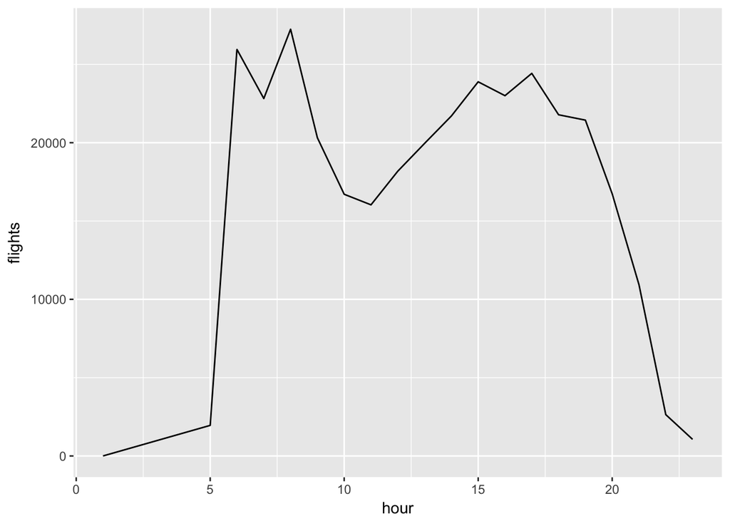

```r
group_by(flightData, hour = hour(time_hour)) %>%
  summarise(flights = n()) %>%
  ggplot() + # we can tack GGPLOT right onto the end with another pipe operator
  geom_line(aes(x = hour, y = flights))
```

# ggplot: Back to Titanic

## Raw Survival Rates

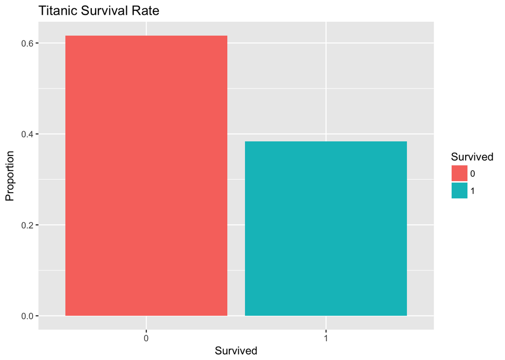

```r
titanicData$Survived %<>% as.factor()

ggplot(titanicData) +
  geom_bar(aes(x = Survived, y = ..count../sum(..count..), fill = Survived)) +
  labs(x = "Survived", y = "Proportion", title = "Titanic Survival Rate")
```

## How did survival rates change with Pclass?

What do you think? Save this as `SurvivalxClass`

```r
# Really Annoying, but here is how we can go back to numeric
titanicData$Survived %<>% as.character() %>% as.numeric()

titanicData$Pclass %<>% as.factor()

SurvivalxClass <- group_by(titanicData, Pclass) %>%
  summarize(Survived = mean(Survived))
```

Let’s visualize it!

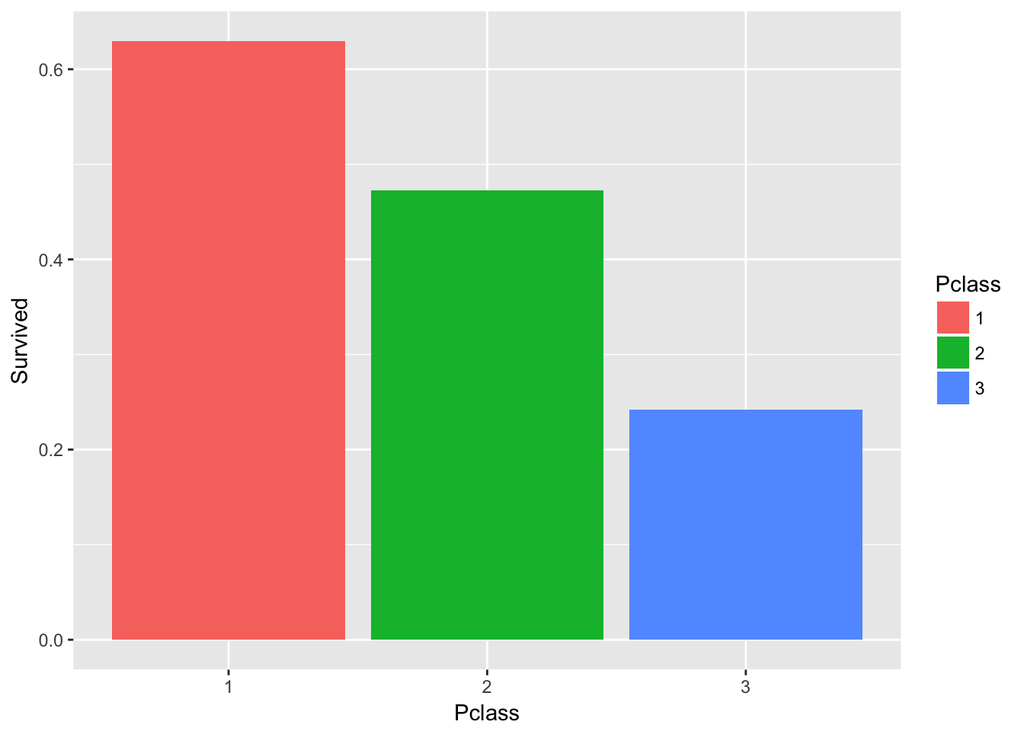

```r
ggplot(SurvivalxClass) +
  geom_col(aes(x = Pclass, y = Survived, fill = Pclass))
```

If the varible we are working off is a factor, it will fill with that. Two main Bar Chart geom:

- `geom_col` gives us the data as it is in the dataset
- `geom_bar` gives you the density by the factor

## Facets: How did our male/female survival change by pclass?

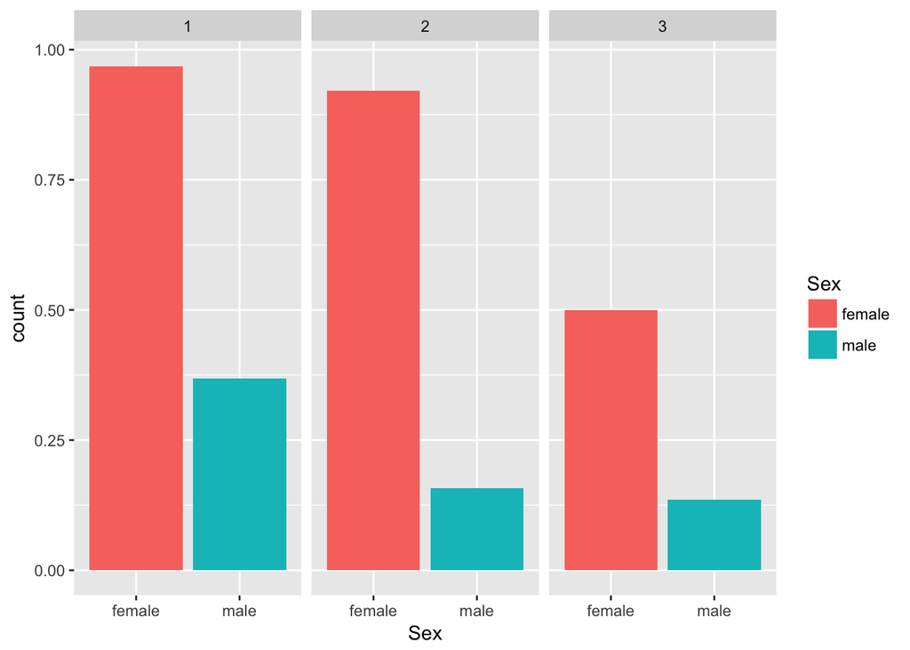

```r
titanicData$Survived %<>% as.character() %>% as.integer()

group_by(titanicData, Pclass, Sex) %>%
  summarise(count = mean(Survived)) %>%
  ggplot() +
  geom_col(aes(x = Sex, y = count, fill = Sex)) +
  facet_grid(. ~ Pclass)
```

## Correlation Plots

What is a correlation?

- Way of gauging how much variation is explained by some data
  $$\frac{Var_x \times Var_y}{n-1}$$
  $$\frac{Cov_{xy}}{(Var_x)(Var_y)}$$

What percent of the individual variance is explained by the convariance? It ranges between negative one and positive one.

## How do we calculate it?

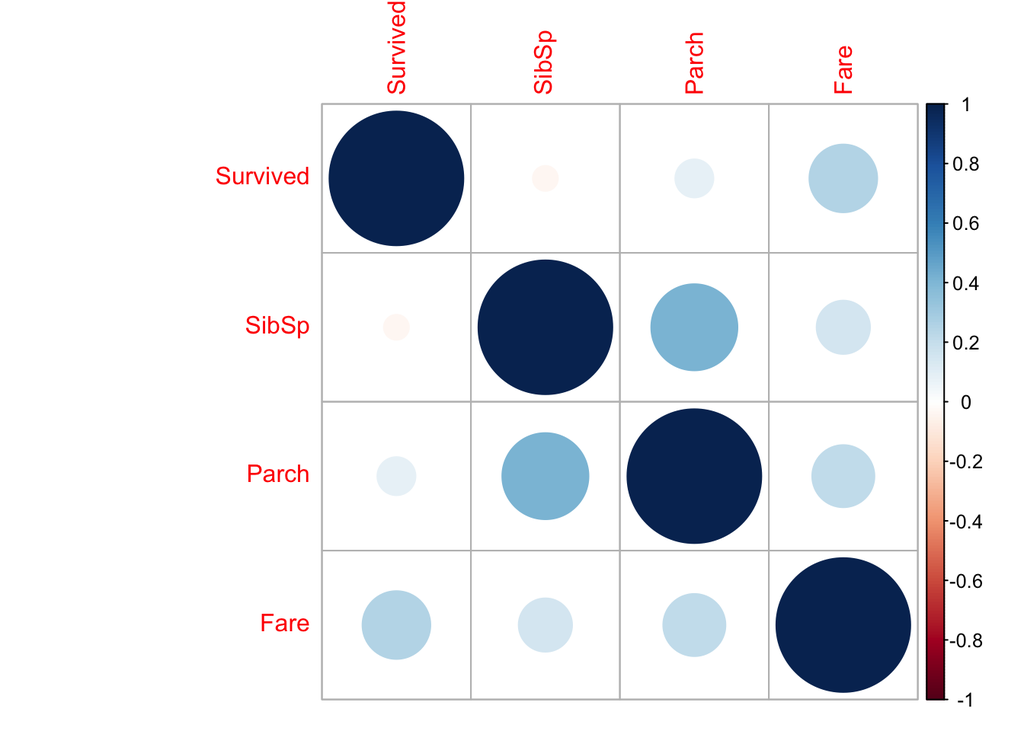

```r
# First, we need to subset to only numeric varibles
subset <- select(titanicData, Survived, SibSp, Parch, Fare)

# Make Correlation
correlation <- cor(subset)

# Plot
library(corrplot)
corrplot(correlation)
```

Not super insightful here.